# dimension_reduction

## Dimension reduction with t-SNE

Visualizing high-dimensional data is an important problem. Some data sets can contain thousands of high-dimensional datapoints. Visualizing a data set with this many dimensions can result in something that is very confusing for your intended audience. In order to visualize this information you have to convert a high-dimensional data set into a 2 or 3 dimensional data set. We will look at t-SNE, a dimensionality reduction method that can help us achieve this goal. Dimensionality reduction is used to preserve as much of the meaningful structure of the high-dimensional data as you convert it to a low-dimensional map.

```python
import matplotlib.pyplot as plt
import numpy as np
from sklearn import manifold
from sklearn.datasets import load_digits
import seaborn as sns
import warnings
warnings.filterwarnings("ignore")

%matplotlib inline
```

We will load the digits data. This is a classic dataset of images of handwritten digits. It contains 1797 images with (8*8=64) pixels each.

```python
digits = load_digits()
digits.data.shape
```

```
(1797, 64)
```

digits.data stores the images:

```python
digits.data[0]
```

```
array([  0.,   0.,   5.,  13.,   9.,   1.,   0.,   0.,   0.,   0.,  13.,
        15.,  10.,  15.,   5.,   0.,   0.,   3.,  15.,   2.,   0.,  11.,
         8.,   0.,   0.,   4.,  12.,   0.,   0.,   8.,   8.,   0.,   0.,
         5.,   8.,   0.,   0.,   9.,   8.,   0.,   0.,   4.,  11.,   0.,
         1.,  12.,   7.,   0.,   0.,   2.,  14.,   5.,  10.,  12.,   0.,
         0.,   0.,   0.,   6.,  13.,  10.,   0.,   0.,   0.])
```

and digits.target is the classes (or labels) that the images belong to. There are 10 classes in total.

```python
digits.target
```

```
array([0, 1, 2, ..., 8, 9, 8])
```

We can display the first image.

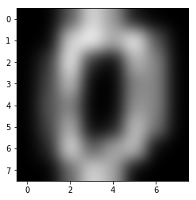

```python
image_shape = (8,8)
plt.imshow( digits.data[0].reshape(image_shape), cmap=plt.cm.gray, interpolation='gaussian' )
```

t-SNE is a method for exploring high-dimensional data."The goal is to take a set of points in a high-dimensional space and find a faithful representation of those points in a lower-dimensional space, typically the 2D plane. The algorithm is non-linear and adapts to the underlying data, performing different transformations on different regions." - [How to Use t-SNE Effectively](https://distill.pub/2016/misread-tsne/)

To run t-SNE, you should first reorder the data points according to the handwritten numbers. You can use [np.vstack](https://docs.scipy.org/doc/numpy/reference/generated/numpy.vstack.html) and [np.hstack](https://docs.scipy.org/doc/numpy/reference/generated/numpy.hstack.html).

```python
X = np.vstack([digits.data[digits.target==i]
               for i in range(10)])
y = np.hstack([digits.target[digits.target==i]
               for i in range(10)])
```

Then initialize a t-sne model. For the meaning of the parameters see [here](http://scikit-learn.org/stable/modules/generated/sklearn.manifold.TSNE.html).

```python
tsne = manifold.TSNE(n_components=2, init='pca', random_state=0)
```

Fit the model on the data.

```python
digits_proj = tsne.fit_transform(X)
```

Plot the results. Seaborn's [hls](http://seaborn.pydata.org/generated/seaborn.hls_palette.html#seaborn.hls_palette) palatte provides evenly spaced colors in HLS hue space, you can divide it into 10 colors.

```python
palette = np.array(sns.color_palette("hls", 10))
```

Make a scatter plot of the first component against the second component, with color based on the numbers.

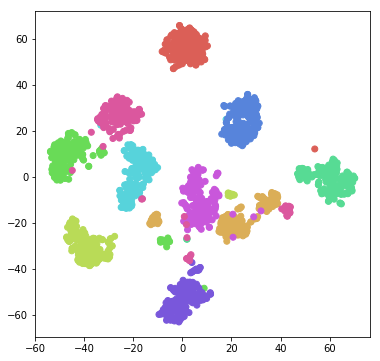

```python
plt.figure(figsize = (6,6))
plt.scatter(digits_proj[:,0], digits_proj[:,1],c=palette[y])
```

t-SNE clearly seperates the digits into clusters. You can add some text to each cluster, with the placement of the text being at the center of the cluster. You can use `np.median` to find the centers. To make it more convenient, you can make the code into a function.

```python
def plot_scatter(projection):
    plt.figure(figsize = (6,6))
    plt.scatter(projection[:,0], projection[:,1],c=palette[y])
    for i in range(10):
        # Position of each label.
        xtext, ytext = np.median(projection[y == i, :], axis=0)
        txt = plt.text(xtext, ytext, str(i), fontsize=24)
```

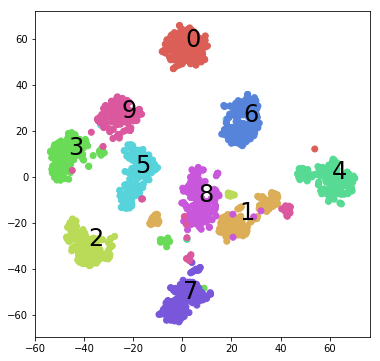

```python
plot_scatter(digits_proj)
```